# Housing Prices

Ozan Aygun

11/26/2017

# 1 Introduction and summary

# 2 Loading the data

```r
train <- read.csv("train.csv"); test <- read.csv("test.csv")
```

# 3 Summarizing the data

```r
summary(train)
```

```
##        Id           MSSubClass       MSZoning     LotFrontage
##  Min.   :   1.0   Min.   : 20.0   C (all):  10   Min.   : 21.00
##  1st Qu.: 365.8   1st Qu.: 20.0   FV     :  65   1st Qu.: 59.00
##  Median : 730.5   Median : 50.0   RH     :  16   Median : 69.00
##  Mean   : 730.5   Mean   : 56.9   RL     :1151   Mean   : 70.05
##  3rd Qu.:1095.2   3rd Qu.: 70.0   RM     : 218   3rd Qu.: 80.00
##  Max.   :1460.0   Max.   :190.0                  Max.   :313.00
##                                                  NA's   :259
##     LotArea        Street      Alley      LotShape  LandContour
##  Min.   :  1300   Grvl:   6   Grvl:  50   IR1:484   Bnk:  63
##  1st Qu.:  7554   Pave:1454   Pave:  41   IR2: 41   HLS:  50
##  Median :  9478               NA's:1369   IR3: 10   Low:  36
##  Mean   : 10517                           Reg:925   Lvl:1311
##  3rd Qu.: 11602
##  Max.   :215245
##
##   Utilities      LotConfig    LandSlope   Neighborhood   Condition1
##  AllPub:1459   Corner : 263   Gtl:1382   NAmes  :225   Norm   :1260
##  NoSeWa:   1   CulDSac:  94   Mod:  65   CollgCr:150   Feedr  :  81
##                FR2    :  47   Sev:  13   OldTown:113   Artery :  48
##                FR3    :   4              Edwards:100   RRAn   :  26
##                Inside :1052              Somerst: 86   PosN   :  19
##                                          Gilbert: 79   RRAe   :  11
##                                          (Other):707   (Other):  15
##    Condition2     BldgType      HouseStyle   OverallQual
##  Norm   :1445   1Fam  :1220   1Story :726   Min.   : 1.000
##  Feedr  :   6   2fmCon:  31   2Story :445   1st Qu.: 5.000
##  Artery :   2   Duplex:  52   1.5Fin :154   Median : 6.000
##  PosN   :   2   Twnhs :  43   SLvl   : 65   Mean   : 6.099
##  RRNn   :   2   TwnhsE: 114   SFoyer : 37   3rd Qu.: 7.000
##  PosA   :   1                 1.5Unf : 14   Max.   :10.000
##  (Other):   2                 (Other): 19
##   OverallCond      YearBuilt     YearRemodAdd    RoofStyle
##  Min.   :1.000   Min.   :1872   Min.   :1950   Flat   :  13
##  1st Qu.:5.000   1st Qu.:1954   1st Qu.:1967   Gable  :1141
##  Median :5.000   Median :1973   Median :1994   Gambrel:  11
##  Mean   :5.575   Mean   :1971   Mean   :1985   Hip    : 286
##  3rd Qu.:6.000   3rd Qu.:2000   3rd Qu.:2004   Mansard:   7
##  Max.   :9.000   Max.   :2010   Max.   :2010   Shed   :   2
##
```

[output cut: 89 more lines]

```
##  GdPrv:  59   Gar2:   2   Min.   :    0.00   Min.   : 1.000
##  GdWo :  54   Othr:   2   1st Qu.:    0.00   1st Qu.: 5.000
##  MnPrv: 157   Shed:  49   Median :    0.00   Median : 6.000
##  MnWw :  11   TenC:   1   Mean   :   43.49   Mean   : 6.322
##  NA's :1179   NA's:1406   3rd Qu.:    0.00   3rd Qu.: 8.000
##                           Max.   :15500.00   Max.   :12.000
##
##      YrSold        SaleType    SaleCondition    SalePrice
##  Min.   :2006   WD     :1267   Abnorml: 101   Min.   : 34900
##  1st Qu.:2007   New    : 122   AdjLand:   4   1st Qu.:129975
##  Median :2008   COD    :  43   Alloca :  12   Median :163000
##  Mean   :2008   ConLD  :   9   Family :  20   Mean   :180921
##  3rd Qu.:2009   ConLI  :   5   Normal :1198   3rd Qu.:214000
##  Max.   :2010   ConLw  :   5   Partial: 125   Max.   :755000
##                 (Other):   9
```

The outcome variable SalePrice is a complete variable, but there are a number of predictors with many missing values. Median house price is $163,000.

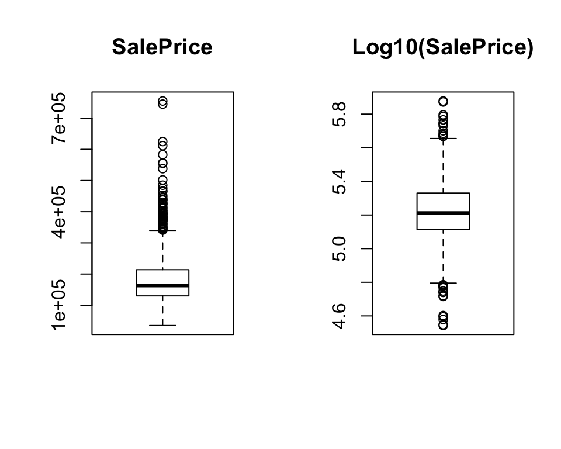

```r
par(mfrow = c(1,2))
boxplot(train$SalePrice,main = "SalePrice")
boxplot(log10(train$SalePrice), main = "Log10(SalePrice)")
```

## 3.1 Understanding the impact of missing data

Which features have more than 30% missing data?

```r
na.status <- is.na(train)
na.sum <- apply(na.status,2,sum)
names(na.sum) <- colnames(train)
mostly_missing <- which(na.sum > (0.3 * nrow(train)))
na.sum[mostly_missing]
```

```
##       Alley FireplaceQu      PoolQC       Fence MiscFeature
##        1369         690        1453        1179        1406
```

5 variables have substantial amount of missing data. Do they have impact on the house prices?

### 3.1.1 Alley

Based on the data description: Type of alley access to property

```
   Grvl     Gravel
   Pave     Paved
   NA       No alley access
```

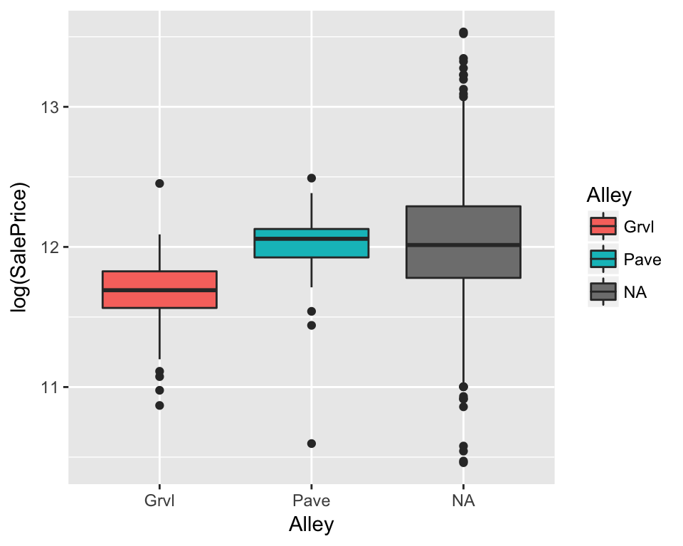

```r
library(ggplot2)

ggplot(data = train, aes(x = Alley, y = log(SalePrice), fill= Alley))+
        geom_boxplot()
```

Alley might be important. Gravel homes have significantly lower price. Convert NAs to “NoAlley” to make more sense.

```r
train$Alley <- as.character(train$Alley)
train$Alley[which(is.na(train$Alley))] <- "NoAlley"
train$Alley <- factor(train$Alley)

#Also transform the test set
test$Alley <- as.character(test$Alley)
test$Alley[which(is.na(test$Alley))] <- "NoAlley"
test$Alley <- factor(test$Alley)
```

### 3.1.2 FireplaceQu

Based on the data description:

FireplaceQu: Fireplace quality

```
   Ex       Excellent - Exceptional Masonry Fireplace
   Gd       Good - Masonry Fireplace in main level
   TA       Average - Prefabricated Fireplace in main living area or Masonry Fireplace in basement
   Fa       Fair - Prefabricated Fireplace in basement
   Po       Poor - Ben Franklin Stove
   NA       No Fireplace
```

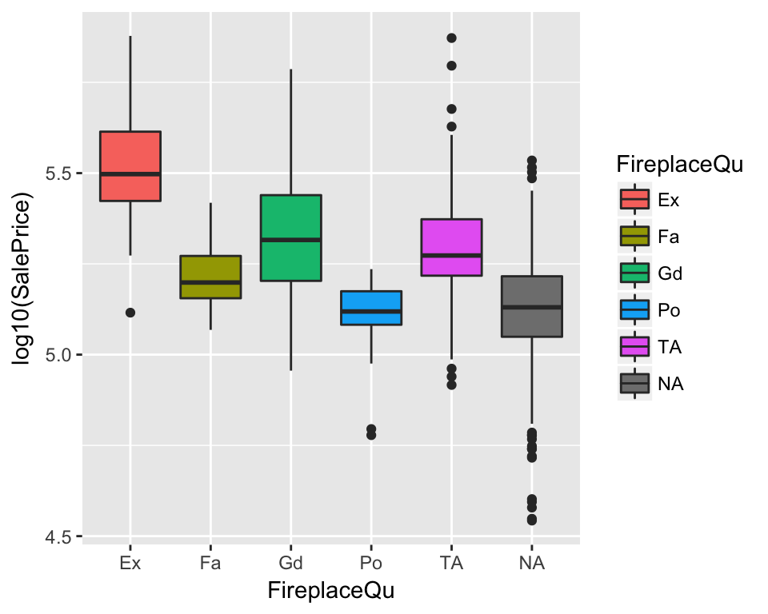

```r
ggplot(data = train, aes(x = FireplaceQu, y = log10(SalePrice), fill= FireplaceQu))+
        geom_boxplot()
```

Let’s look at through a simple linear model:

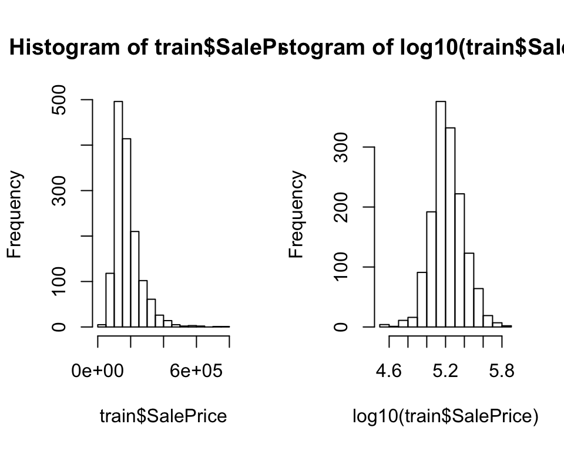

```r
par(mfrow=c(1,2))
hist(train$SalePrice)
hist(log10(train$SalePrice)) # Looks more gaussian
```

```r
FirePlaceFit <- lm(log10(train$SalePrice) ~ FireplaceQu, data = train)
summary(FirePlaceFit)
```

```
##
## Call:
## lm(formula = log10(train$SalePrice) ~ FireplaceQu, data = train)
##
## Residuals:
##      Min       1Q   Median       3Q      Max
## -0.38691 -0.09351 -0.01374  0.09604  0.57966
##
## Coefficients:
##               Estimate Std. Error t value Pr(>|t|)
## (Intercept)    5.50252    0.03013 182.644  < 2e-16 ***
## FireplaceQuFa -0.28729    0.03959  -7.256 9.82e-13 ***
## FireplaceQuGd -0.17957    0.03106  -5.781 1.08e-08 ***
## FireplaceQuPo -0.40442    0.04469  -9.050  < 2e-16 ***
## FireplaceQuTA -0.21003    0.03126  -6.719 3.58e-11 ***
## ---
## Signif. codes:  0 '***' 0.001 '**' 0.01 '*' 0.05 '.' 0.1 ' ' 1
##
## Residual standard error: 0.1476 on 765 degrees of freedom
##   (690 observations deleted due to missingness)
## Multiple R-squared:  0.118,  Adjusted R-squared:  0.1134
## F-statistic: 25.59 on 4 and 765 DF,  p-value: < 2.2e-16
```

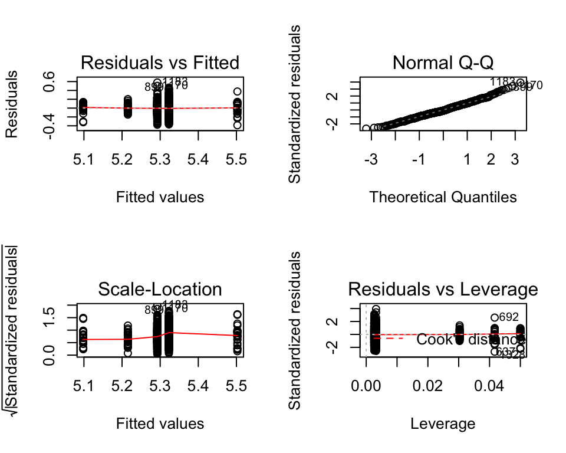

```r
par(mfrow=c(2,2))
plot(FirePlaceFit)
```

It appears that all levels of this feature also have significantly different mean Sales prices. Again, converting NAs to NoFireplace to be more informative.

```r
train$FireplaceQu <- as.character(train$FireplaceQu)
train$FireplaceQu[which(is.na(train$FireplaceQu))] <- "NoFireplace"
train$FireplaceQu <- factor(train$FireplaceQu)

#Also transform the test set
test$FireplaceQu <- as.character(test$FireplaceQu)
test$FireplaceQu[which(is.na(test$FireplaceQu))] <- "NoFireplace"
test$FireplaceQu <- factor(test$FireplaceQu)
```

### 3.1.3 PoolQC

Based on the data description:

```
    PoolQC: Pool quality
           Ex       Excellent
           Gd       Good
           TA       Average/Typical
           Fa       Fair
           NA       No Pool
```

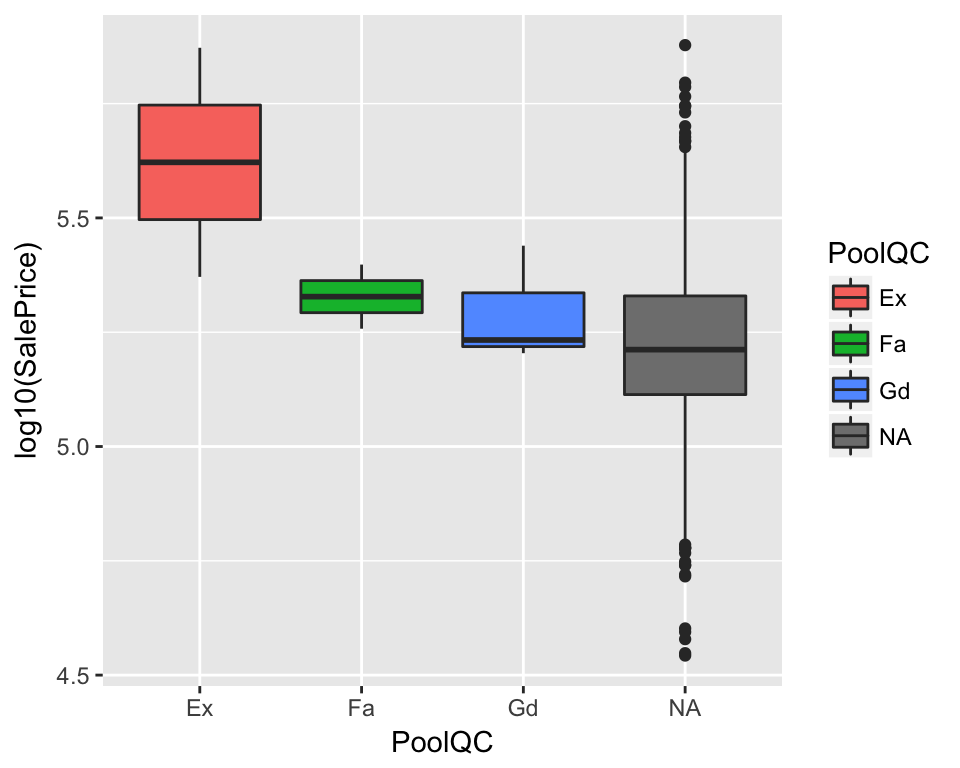

```r
library(ggplot2)
ggplot(data = train, aes(x = PoolQC, y = log10(SalePrice), fill = PoolQC))+
        geom_boxplot()
```

Note that actually very few houses have pools. Houses with excellent pool condition have significantly higher sales prices. We will also keep this feature, converting NAs to “NoPool”:

```r
train$PoolQC <- as.character(train$PoolQC)
train$PoolQC[which(is.na(train$PoolQC))] <- "NoPool"
train$PoolQC <- factor(train$PoolQC)

#Also transform the test set
test$PoolQC <- as.character(test$PoolQC)
test$PoolQC[which(is.na(test$PoolQC))] <- "NoPool"
test$PoolQC <- factor(test$PoolQC)
```

### 3.1.4 Fence

Based on the data description:

```
    Fence: Fence quality
           GdPrv    Good Privacy
           MnPrv    Minimum Privacy
           GdWo     Good Wood
           MnWw     Minimum Wood/Wire
           NA       No Fence
```

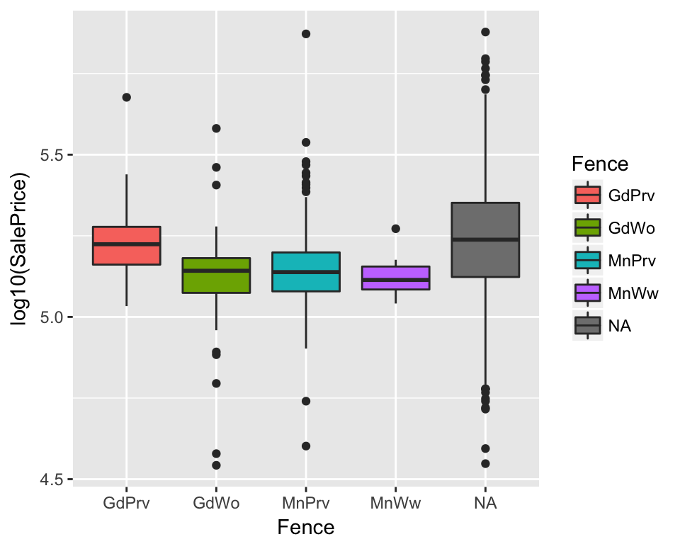

```r
library(ggplot2)
ggplot(data = train, aes(x = Fence, y = log10(SalePrice), fill = Fence))+
        geom_boxplot()
```

```r
FenceFit <- lm(log10(train$SalePrice) ~ Fence, data = train)
summary(FenceFit)
```

```
##
## Call:
## lm(formula = log10(train$SalePrice) ~ Fence, data = train)
##
## Residuals:
##      Min       1Q   Median       3Q      Max
## -0.57500 -0.06747 -0.00520  0.05611  0.72551
##
## Coefficients:
##             Estimate Std. Error t value Pr(>|t|)
## (Intercept)  5.23634    0.01816 288.272  < 2e-16 ***
## FenceGdWo   -0.11851    0.02628  -4.510 9.58e-06 ***
## FenceMnPrv  -0.08969    0.02131  -4.210 3.46e-05 ***
## FenceMnWw   -0.11305    0.04582  -2.467   0.0142 *
## ---
## Signif. codes:  0 '***' 0.001 '**' 0.01 '*' 0.05 '.' 0.1 ' ' 1
##
## Residual standard error: 0.1395 on 277 degrees of freedom
##   (1179 observations deleted due to missingness)
## Multiple R-squared:  0.08211,    Adjusted R-squared:  0.07217
## F-statistic:  8.26 on 3 and 277 DF,  p-value: 2.781e-05
```

Interestingly, this feature might have a complex relationship, if any at all, with the response variable. The effects of each of the level deemed as significant, so we will keep this feature at this point as well.

```r
train$Fence <- as.character(train$Fence)
train$Fence[which(is.na(train$Fence))] <- "NoFence"
train$Fence <- factor(train$Fence)

#Also transform the test set
test$Fence <- as.character(test$Fence)
test$Fence[which(is.na(test$Fence))] <- "NoFence"
test$Fence <- factor(test$Fence)
```

### 3.1.5 MiscFeature

Based on the data description:

```
    MiscFeature: Miscellaneous feature not covered in other categories
           Elev     Elevator
           Gar2     2nd Garage (if not described in garage section)
           Othr     Other
           Shed     Shed (over 100 SF)
           TenC     Tennis Court
           NA       None
```

We will deal with the remaining missing value containing features in the next stages of our analysis.

```r
table(train$MiscFeature)
```

```
##
## Gar2 Othr Shed TenC
##    2    2   49    1
```

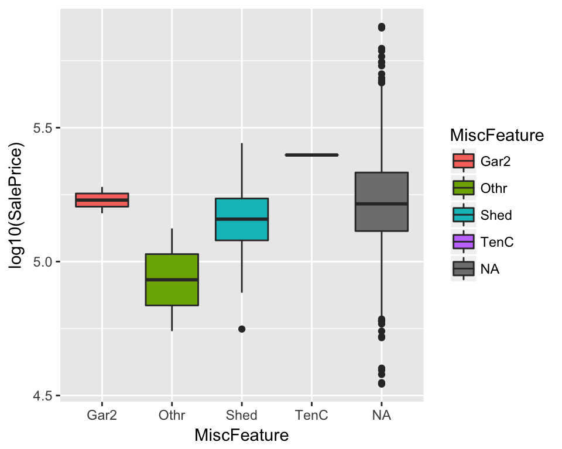

```r
ggplot(data = train, aes(x = MiscFeature, y = log10(SalePrice), fill = MiscFeature))+
        geom_boxplot()
```

Again, very few houses have this features, and not sure if these qualities have a real impact on the house value amongst other measured features. Neverthless, I will maintain this feature as well. Just converting NAs to “NoMiscFeature” to be more clear:

```r
train$MiscFeature <- as.character(train$MiscFeature)
train$MiscFeature[which(is.na(train$MiscFeature))] <- "NoMiscFeature"
train$MiscFeature <- factor(train$MiscFeature)

#Also transform the test set
test$MiscFeature <- as.character(test$MiscFeature)
test$MiscFeature[which(is.na(test$MiscFeature))] <- "NoMiscFeature"
test$MiscFeature <- factor(test$MiscFeature)
```

# 4 Developing expectations from data

Here I will explore the data further, in order to develope a better understanding about the relationships between features and the home prices.

## 4.1 Watching for potential collinearities

Let’s look at the continuous features in the data set:

```r
cont.var <-NULL
for(i in 1:ncol(train)){
        if(class(train[,i]) == "integer" | class(train[,i]) == "numeric"){
                cont.var <- c(cont.var,i)
        }
}
```

### 4.1.1 Part1

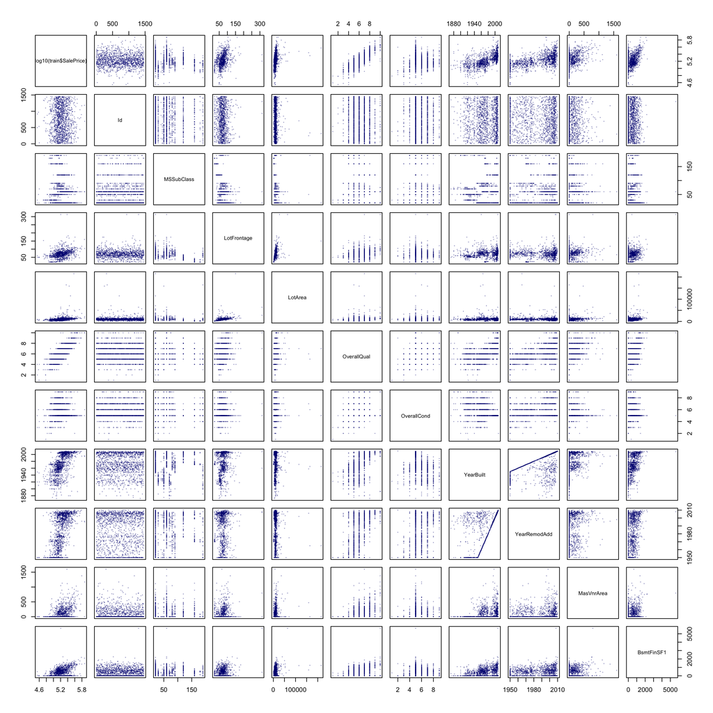

```r
pairs(log10(train$SalePrice) ~ ., data = train[,cont.var[1:10]], cex = 0.05, pch = 19, col = "navy")
```

- We need to remove ID, since this is just an identifier for the houses, has no predictive value as expected.
- OverallQual and OverallCond look strong predictors, but might have some collinearity.
- Yearbuilt and YearRemodAdd also look good predictors but most likely contain redundant information.
- For the LOT and SF features, it could be better to look at after log transformation, since the data looks skewed.

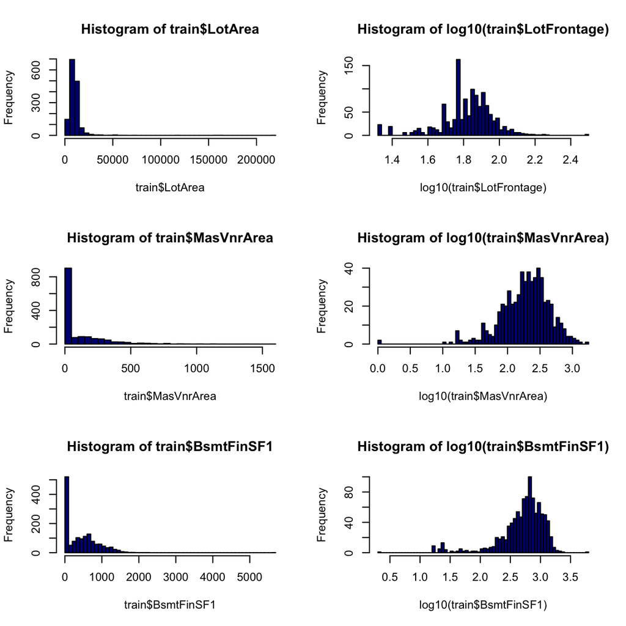

```r
par(mfrow=c(3,2))
hist(train$LotArea, breaks = 50, col = "navy");hist(log10(train$LotFrontage),breaks=50,col = "navy")
hist(train$MasVnrArea, breaks = 50,col = "navy");hist(log10(train$MasVnrArea),breaks=50,col = "navy")
hist(train$BsmtFinSF1, breaks = 50,col = "navy");hist(log10(train$BsmtFinSF1),breaks=50,col = "navy")
```

Indeed these features look more gaussian when they are is log10 transformed.

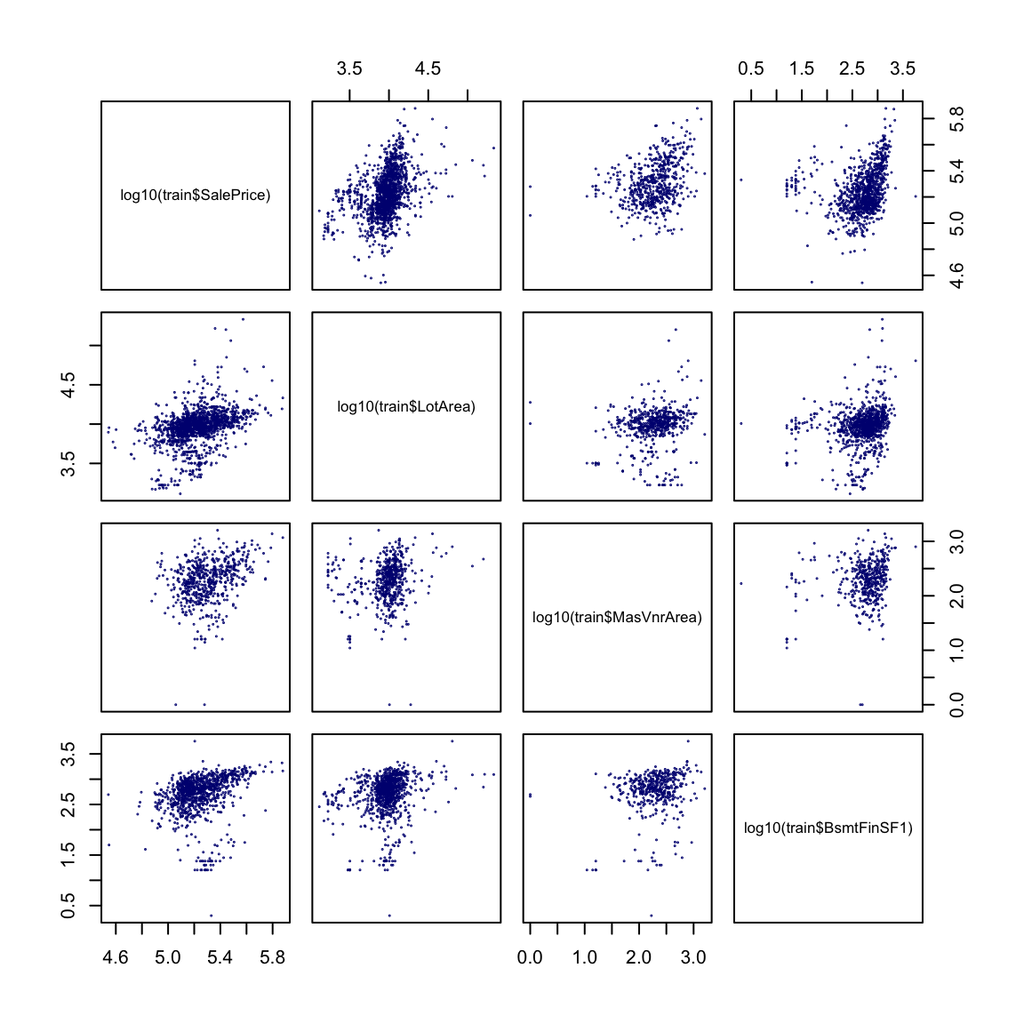

```r
pairs(log10(train$SalePrice) ~ log10(train$LotArea) + log10(train$MasVnrArea) + log10(train$BsmtFinSF1),cex = 0.1, pch = 19, col = "navy")
```

When transformed, these features seem to do a better job in explain the variability in the response variable.

Therefore, we will log10 transform these 3 variables in both training and test data sets: